# Data Storage

ozge.ozdamar@msgsu.edu.tr

October 28 2021

İSTANBUL KÜLTÜR ÜNİVERSİTESİ - MB0072 NESNE YÖNELİMLİ PROGRAMLAMA1 by ozge.ozdamar@msgsu.edu.tr is licensed under a [Creative Commons Attribution-NonCommercial-ShareAlike 4.0 International License](http://creativecommons.org/licenses/by-nc-sa/4.0/).

Hata ve öneriler için ✉️

**REFERENCES**

**Links**

[Advanced R](https://adv-r.hadley.nz)

**Cheat Sheets**

[figure not shown]

Base R Cheat Sheet

[figure not shown]

Atomic Vectors Cheat Sheet

[figure not shown]

Data.frame Cheat Sheet

[figure not shown]

Matrix and Arrays Cheat Sheet

[figure not shown]

Lists Cheat Sheet

[figure not shown]

Factors Cheat Sheet

[figure not shown]

Factors Cheat Sheet

[figure not shown]

Useful Functions Cheat Sheet

**LIBRARIES**

```r
.packages = c("pryr","lobstr")
.inst <- .packages %in% installed.packages()
if(length(.packages[!.inst]) > 0) install.packages(.packages[!.inst])
lapply(.packages, require, character.only=TRUE)
```

# 1 Data Types

## 1.1 Character

```r
VC<-"merhaba"
VC
```

```
## [1] "merhaba"
```

```r
class(VC)
```

```
## [1] "character"
```

```r
typeof(VC)
```

```
## [1] "character"
```

```r
mode(VC)
```

```
## [1] "character"
```

```r
storage.mode(VC)
```

```
## [1] "character"
```

```r
str(VC)
```

```
##  chr "merhaba"
```

```r
attributes(VC)
```

```r
object.size(VC) # utils package
```

```
## 112 bytes
```

```r
lobstr::obj_size(VC) # lobstr package
```

```
## 112 B
```

```r
tracemem(VC) # base package
```

```
## [1] "<0x11c1022f8>"
```

```r
lobstr::obj_addr(VC)
```

```
## [1] "0x11c1022f8"
```

```r
is.vector(VC)
```

```
## [1] TRUE
```

## 1.2 Numeric (real or decimal)

```r
VN1<-5
VN2<-5.5
VN1
```

```
## [1] 5
```

```r
VN2
```

```
## [1] 5.5
```

```r
class(VN1)
```

```
## [1] "numeric"
```

```r
class(VN2)
```

```
## [1] "numeric"
```

```r
typeof(VN1)
```

```
## [1] "double"
```

```r
typeof(VN2)
```

```
## [1] "double"
```

```r
mode(VN1)
```

```
## [1] "numeric"
```

```r
mode(VN2)
```

```
## [1] "numeric"
```

```r
storage.mode(VN1)
```

```
## [1] "double"
```

```r
storage.mode(VN2)
```

```
## [1] "double"
```

```r
str(VN1)
```

```
##  num 5
```

```r
str(VN2)
```

```
##  num 5.5
```

```r
attributes(VN1)
```

```r
attributes(VN2)
```

```r
object.size(VN1)
```

```
## 56 bytes
```

```r
object.size(VN2)
```

```
## 56 bytes
```

```r
lobstr::obj_size(VN1)
```

```
## 56 B
```

```r
lobstr::obj_size(VN2)
```

```
## 56 B
```

```r
tracemem(VN1)
```

```
## [1] "<0x12ccef130>"
```

```r
tracemem(VN2)
```

```
## [1] "<0x12ccef0c0>"
```

```r
lobstr::obj_addr(VN1)
```

```
## [1] "0x12ccef130"
```

```r
lobstr::obj_addr(VN2)
```

```
## [1] "0x12ccef0c0"
```

## 1.3 Logical

```r
VL<-TRUE
VL
```

```
## [1] TRUE
```

```r
class(VL)
```

```
## [1] "logical"
```

```r
typeof(VL)
```

```
## [1] "logical"
```

```r
mode(VL)
```

```
## [1] "logical"
```

```r
storage.mode(VL)
```

```
## [1] "logical"
```

```r
str(VL)
```

```
##  logi TRUE
```

```r
attributes(VL)
```

```r
object.size(VL)
```

```
## 56 bytes
```

```r
lobstr::obj_size(VL)
```

```
## 56 B
```

```r
tracemem(VL)
```

```
## [1] "<0x11b8a8940>"
```

```r
lobstr::obj_addr(VL)
```

```
## [1] "0x11b8a8940"
```

## 1.4 Integer

```r
VI<-5L
VI
```

```
## [1] 5
```

```r
class(VI)
```

```
## [1] "integer"
```

```r
typeof(VI)
```

```
## [1] "integer"
```

```r
mode(VI)
```

```
## [1] "numeric"
```

```r
storage.mode(VI)
```

```
## [1] "integer"
```

```r
str(VI)
```

```
##  int 5
```

```r
attributes(VI)
```

```r
object.size(VI)
```

```
## 56 bytes
```

```r
lobstr::obj_size(VI)
```

```
## 56 B
```

```r
tracemem(VI)
```

```
## [1] "<0x11c4b1de0>"
```

```r
lobstr::obj_addr(VI)
```

```
## [1] "0x11c4b1de0"
```

## 1.5 Complex number

```r
VCN<-5+2i
VCN
```

```
## [1] 5+2i
```

```r
class(VCN)
```

```
## [1] "complex"
```

```r
typeof(VCN)
```

```
## [1] "complex"
```

```r
mode(VCN)
```

```
## [1] "complex"
```

```r
storage.mode(VCN)
```

```
## [1] "complex"
```

```r
str(VCN)
```

```
##  cplx 5+2i
```

```r
attributes(VCN)
```

```r
object.size(VCN)
```

```
## 64 bytes
```

```r
lobstr::obj_size(VCN)
```

```
## 64 B
```

```r
tracemem(VCN)
```

```
## [1] "<0x11cdac9c8>"
```

```r
lobstr::obj_addr(VCN)
```

```
## [1] "0x11cdac9c8"
```

## 1.6 Raw data(byte)

```r
VR <-charToRaw("merhaba") # Raw
VR
```

```
## [1] 6d 65 72 68 61 62 61
```

```r
class(VR)
```

```
## [1] "raw"
```

```r
typeof(VR)
```

```
## [1] "raw"
```

```r
mode(VR)
```

```
## [1] "raw"
```

```r
storage.mode(VR)
```

```
## [1] "raw"
```

```r
str(VR)
```

```
##  raw [1:7] 6d 65 72 68 ...
```

```r
attributes(VR)
```

```r
object.size(VR)
```

```
## 56 bytes
```

```r
lobstr::obj_size(VR)
```

```
## 56 B
```

```r
tracemem(VR)
```

```
## [1] "<0x13bca7438>"
```

```r
lobstr::obj_addr(VR)
```

```
## [1] "0x13bca7438"
```

# 2 Data Structures

Variables are nothing but reserved memory locations to store values. This means that, when you create a variable you reserve some space in memory.

You may like to store information of various data types like character, wide character, integer, floating point, double floating point, Boolean etc. Based on the data type of a variable, the operating system allocates memory and decides what can be stored in the reserved memory.

However, one difference of R Programming to other programming languages, such as Java and C, is the fact that variables need not be necessarily declared as data types. The variables are assigned with R-Objects and the data type of the R-object becomes the data type of the variable. R data types are:

| object | nesne |  |
| --- | --- | --- |
| Vector | vektör | ayni tiple bilgi içeren en küçük nesne |
| Array | dizi | birden fazla boyutta bilgi içeren nesne |
| Matrice | matris | matris. matris aynı tipte ve uzunlukta bilgi içerir ve zamanda 2 boyutlu array dir |
| Data.frame | veri seti | farklı tipte bilgi(numeric, character,factor) içerebilen nesne |
| Factor | faktör | kategorik değişkenler için kullanılır |
| List | liste | farkli tipte nesneleri barindirabilen nesne |
| ts | zaman serisi | zaman serisi |

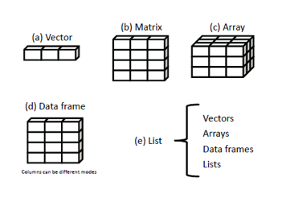

- ps: R’da bu temel nesne tiplerinden başka farklı amaçlar için oluşturulmuş nesneler de vardır. İlgili paketlerin yüklenmesiyle bu nesneler ile çalışabiliriz.

## 2.1 Vector

The basic data structure in R is the vector.There are two types of vectors

- **Atomic vectors:** logical, integer, double, character, complex, and raw. Integer and double vectors are collectively known as numeric vectors.
- **Lists:** which are sometimes called recursive vectors because lists can contain other lists.

Atomic vectors are homogeneous, while lists can be heterogeneous.

There’s one other related object: NULL. NULL is often used to represent the absence of a vector (as opposed to NA, which is used to represent the absence of a value in a vector). NULL typically behaves like a vector of length 0.

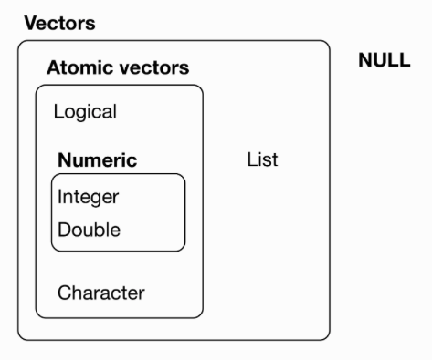

Vectors have three common properties:

- **Type:** `typeof()`, what it is.
- **Length:** `length()`, how many elements it contains.
- **Attributes:** `attributes()`, additional arbitrary metadata.

vectors contain the same type / mode values

scaler values are vectors with only one element.

Basic information of any kind of objects in R can be gathered with `mode()`, `class()`, `typeof()`, `storage.mode()`, `attributes()` functions.

**`mode`** is a mutually exclusive classification of objects according to their basic structure. The ‘atomic’ modes are numeric, complex, character and logical. Recursive objects have modes such as ‘list’ or ‘function’ or a few others. An object has one and only one mode.

For the numeric mode, R stores all numeric objects into either a 32-bit integer or a double-precision floating point.

If an R object contains both numeric and logical elements, the mode of that object will be numeric and, in this case, the logical element automatically gets converted to a numeric element. The logical element TRUE converts to 1 and FALSE converts to 0. On the other hand, if any R object contains a character element, along with both numeric and logical elements, it automatically converts to the character mode.

**`class`** is a property assigned to an object that determines how generic functions operate with it. It is not a mutually exclusive classification. If an object has no specific class assigned to it, such as a simple numeric vector, it’s class is usually the same as its mode, by convention.

Changing the mode of an object is often called ‘coercion’. The mode of an object can change without necessarily changing the class.

http://www.diegobarneche.com/2014-12-11-ufsc/lessons/01-intro_r/data-structures.html

**examples**

```r
x <- c(1,2,3)
x
```

```
## [1] 1 2 3
```

```r
class(x)
```

```
## [1] "numeric"
```

```r
mode(x)
```

```
## [1] "numeric"
```

```r
typeof(x)
```

```
## [1] "double"
```

```r
storage.mode(x)
```

```
## [1] "double"
```

```r
attributes(x)
```

```r
object_size(x)
```

```
## 80 B
```

```r
tracemem(x)
```

```
## [1] "<0x12cd0daa8>"
```

```r
length(x)
```

```
## [1] 3
```

```r
is.vector(x)
```

```
## [1] TRUE
```

```r
y<-x
y
```

```
## [1] 1 2 3
```

```r
tracemem(x)
```

```
## [1] "<0x12cd0daa8>"
```

```r
tracemem(y)
```

```
## [1] "<0x12cd0daa8>"
```

These identifiers are long, and change every time you restart R.

```r
y[3]<-4
```

```
## tracemem[0x12cd0daa8 -> 0x11c9226b8]: eval eval withVisible withCallingHandlers handle timing_fn evaluate_call <Anonymous> evaluate in_dir eng_r block_exec call_block process_group.block process_group withCallingHandlers process_file <Anonymous> <Anonymous>
```

```r
tracemem(x)
```

```
## [1] "<0x12cd0daa8>"
```

```r
tracemem(y)
```

```
## [1] "<0x11c9226b8>"
```

This behaviour is called copy-on-modify.

### 2.1.1 Vector Types

#### 2.1.1.1 Locigal vector

```r
v.logical1 <- c(TRUE,F,T,FALSE)
v.logical2 <- c(T,FALSE,F,T)
v.logical1
```

```
## [1]  TRUE FALSE  TRUE FALSE
```

```r
class(v.logical1)
```

```
## [1] "logical"
```

```r
typeof(v.logical1)
```

```
## [1] "logical"
```

```r
mode(v.logical1)
```

```
## [1] "logical"
```

Logical vectors are usually constructed with comparison operators.

```r
1:10 >= 5
```

```
##  [1] FALSE FALSE FALSE FALSE  TRUE  TRUE  TRUE  TRUE  TRUE  TRUE
```

```r
!(1:10 >= 5)
```

```
##  [1]  TRUE  TRUE  TRUE  TRUE FALSE FALSE FALSE FALSE FALSE FALSE
```

```r
1:10 %% 3 == 0
```

```
##  [1] FALSE FALSE  TRUE FALSE FALSE  TRUE FALSE FALSE  TRUE FALSE
```

`any()` is at least one of the values true

```r
any(v.logical1)
```

```
## [1] TRUE
```

```r
any(v.logical2)
```

```
## [1] TRUE
```

`all()` are all of the values true

```r
all(v.logical1)
```

```
## [1] FALSE
```

```r
all(v.logical2)
```

```
## [1] FALSE
```

```r
v.logical1 & v.logical2
```

```
## [1]  TRUE FALSE FALSE FALSE
```

```r
v.logical1 | v.logical2
```

```
## [1]  TRUE FALSE  TRUE  TRUE
```

**understanding logical vectors / operators**

```r
x <- c(TRUE, FALSE, NA)
xy <- expand.grid(x = x, y = x)
within(xy,{
and <- x & y
or <- x | y
not.y <- !y
not.x <- !x
}
)
```

| x | y | not.x | not.y | or | and |
| --- | --- | --- | --- | --- | --- |
| TRUE | TRUE | FALSE | FALSE | TRUE | TRUE |
| FALSE | TRUE | TRUE | FALSE | TRUE | FALSE |
| NA | TRUE | NA | FALSE | TRUE | NA |
| TRUE | FALSE | FALSE | TRUE | TRUE | FALSE |
| FALSE | FALSE | TRUE | TRUE | FALSE | FALSE |
| NA | FALSE | NA | TRUE | NA | FALSE |
| TRUE | NA | FALSE | NA | TRUE | NA |
| FALSE | NA | TRUE | NA | NA | FALSE |
| NA | NA | NA | NA | NA | NA |

#### 2.1.1.2 Integer vector

Integer and double vectors are known collectively as numeric vectors. In R, numbers are doubles by default. To make an integer, place a L after the number

```r
v.integer <- c(1L,2L,4L)  # Integer :: This indicates the values of OL, 2L, 34L.
v.integer
```

```
## [1] 1 2 4
```

```r
class(v.integer)
```

```
## [1] "integer"
```

```r
typeof(v.integer)
```

```
## [1] "integer"
```

```r
mode(v.integer)
```

```
## [1] "numeric"
```

#### 2.1.1.3 Double vector

```r
v.double <- c(1,2,4.5)
v.double
```

```
## [1] 1.0 2.0 4.5
```

```r
class(v.double)
```

```
## [1] "numeric"
```

```r
typeof(v.double)
```

```
## [1] "double"
```

```r
mode(v.double)
```

```
## [1] "numeric"
```

The distinction between integers and doubles:

Doubles are approximations. Doubles represent floating-point numbers that cannot always be precisely represented with a fixed amount of memory. This means that you should consider all doubles to be approximations.

```r
s1<-c(10L,11L)
s2<-c(10,11)
```

```r
typeof(s1)
```

```
## [1] "integer"
```

```r
typeof(s2)
```

```
## [1] "double"
```

```r
object.size(s1)
```

```
## 56 bytes
```

```r
object.size(s2)
```

```
## 64 bytes
```

```r
s3<-as.integer(s2)
object.size(s3)
```

```
## 56 bytes
```

```r
x <- sqrt(2) ^ 2
x
```

```
## [1] 2
```

```r
x - 2
```

```
## [1] 4.440892e-16
```

This behavior is common when working with floating-point numbers: most calculations include some approximation error. Instead of comparing floating-point numbers using `==`, you should use `dplyr::near()`, which allows for some numerical tolerance.

Integers have one special value, `NA`, while doubles have four, `NA`, `NaN`, `Inf`, and `-Inf`. All three special values can arise during division

```r
c(-1, 0, 1) / 0
```

```
## [1] -Inf  NaN  Inf
```

Avoid using `==`to check for these other special values. Instead use the helper functions `is.finite()`, `is.infinite()`, and `is.nan()`

#### 2.1.1.4 Character vector

Character vectors are the most complex type of atomic vector, because each element of a character vector is a string, and a string can contain an arbitrary amount of data.

R uses a global string pool. This means that each unique string is only stored in memory once, and every use of the string points to that representation. This reduces the amount of memory needed by duplicated strings.

```r
v.char1 <-"M" # same 'M'
v.char1
```

```
## [1] "M"
```

```r
class(v.char1)
```

```
## [1] "character"
```

```r
typeof(v.char1)
```

```
## [1] "character"
```

```r
mode(v.char1)
```

```
## [1] "character"
```

```r
object.size(v.char1)
```

```
## 112 bytes
```

```r
v.char2<-rep(v.char1,100)
object.size(v.char2)
```

```
## 904 bytes
```

`v.char2` doesn’t take up 100x as much memory as `v.char1`, because each element of `v.char2` is just a pointer to that same string. A pointer is 8 bytes.

#### 2.1.1.5 Complex vector

```r
v.complex <- c(2+5i,1+2i) # Complex
v.complex
```

```
## [1] 2+5i 1+2i
```

```r
class(v.complex)
```

```
## [1] "complex"
```

```r
typeof(v.complex)
```

```
## [1] "complex"
```

```r
mode(v.complex)
```

```
## [1] "complex"
```

#### 2.1.1.6 Raw vector

```r
v.raw <-charToRaw("merhaba") # raw
v.raw
```

```
## [1] 6d 65 72 68 61 62 61
```

```r
class(v.raw)
```

```
## [1] "raw"
```

```r
typeof(v.raw)
```

```
## [1] "raw"
```

```r
mode(v.raw)
```

```
## [1] "raw"
```

Missing values are specified with `NA`, which is a logical vector of length 1. `NA` will always be coerced to the correct type if used inside `c()`, or you can create `NA`s of a specific type with `NA_real_` (a double vector), `NA_integer_` and `NA_character_`.

- Note that each type of atomic vector has its own missing value

```r
NA             # logical
```

```
## [1] NA
```

```r
NA_integer_    # integer
```

```
## [1] NA
```

```r
NA_real_       # double
```

```
## [1] NA
```

```r
NA_character_  # character
```

```
## [1] NA
```

Normally you don’t need to know about these different types because you can always use `NA` and it will be converted to the correct type using the implicit coercion rules described next. However, there are some functions that are strict about their inputs, so it’s useful to have this knowledge sitting in your back pocket so you can be specific when needed.

NB: `is.numeric()` is a general test for the “numberliness” of a vector and returns `TRUE` for both integer and double vectors. It is not a specific test for double vectors, which are often called numeric.

### 2.1.2 Creating vector

**concatenating data to create vectors**

concatenate is a Latin word meaning connect together in a chain `c()`

```r
a1 <- c(1,2,3,4,5,6,7,8,9,10)
a1
```

```
##  [1]  1  2  3  4  5  6  7  8  9 10
```

create sequantial vectors with `:`, `rep()` and `seq()`

```r
a1 <- 1:10
a1
```

```
##  [1]  1  2  3  4  5  6  7  8  9 10
```

```r
seq(from = 1, to = 10, by = 2)
```

```
## [1] 1 3 5 7 9
```

```r
seq(from = 1, to = 10, length.out =6) # lenght=6
```

```
## [1]  1.0  2.8  4.6  6.4  8.2 10.0
```

```r
seq(3, 0, -1)
```

```
## [1] 3 2 1 0
```

```r
rep(1, 5)
```

```
## [1] 1 1 1 1 1
```

```r
rep(c(1,2), 5)
```

```
##  [1] 1 2 1 2 1 2 1 2 1 2
```

```r
rep(c(1,2), each=5) #?rep
```

```
##  [1] 1 1 1 1 1 2 2 2 2 2
```

```r
isim <- c("D1", "D2", "D3") # char vector
```

```r
rep(isim,each=10)
```

```
##  [1] "D1" "D1" "D1" "D1" "D1" "D1" "D1" "D1" "D1" "D1" "D2" "D2" "D2" "D2" "D2"
## [16] "D2" "D2" "D2" "D2" "D2" "D3" "D3" "D3" "D3" "D3" "D3" "D3" "D3" "D3" "D3"
```

```r
rep(isim,10)
```

```
##  [1] "D1" "D2" "D3" "D1" "D2" "D3" "D1" "D2" "D3" "D1" "D2" "D3" "D1" "D2" "D3"
## [16] "D1" "D2" "D3" "D1" "D2" "D3" "D1" "D2" "D3" "D1" "D2" "D3" "D1" "D2" "D3"
```

```r
(v1 <- 1:10)
```

```
##  [1]  1  2  3  4  5  6  7  8  9 10
```

```r
(v2 <- c(11:13,NA,15:17,NA,19,20)) # with missing values
```

```
##  [1] 11 12 13 NA 15 16 17 NA 19 20
```

```r
(v3 <- seq(1,100,10))
```

```
##  [1]  1 11 21 31 41 51 61 71 81 91
```

binding vectors

```r
V1<-c(v1,v2,v3)
V1
```

```
##  [1]  1  2  3  4  5  6  7  8  9 10 11 12 13 NA 15 16 17 NA 19 20  1 11 21 31 41
## [26] 51 61 71 81 91
```

```r
sum(v2)
```

```
## [1] NA
```

```r
sum(v2, na.rm=TRUE) #? ve ??
```

```
## [1] 123
```

cbind (COLUMN BIND)

```r
V2<-cbind(v1,v2,v3)
V2
```

```
##       v1 v2 v3
##  [1,]  1 11  1
##  [2,]  2 12 11
##  [3,]  3 13 21
##  [4,]  4 NA 31
##  [5,]  5 15 41
##  [6,]  6 16 51
##  [7,]  7 17 61
##  [8,]  8 NA 71
##  [9,]  9 19 81
## [10,] 10 20 91
```

```r
class(V2)
```

```
## [1] "matrix" "array"
```

```r
dim(V2)
```

```
## [1] 10  3
```

rbind (ROW BIND)

```r
V3<-rbind(v1,v2,v3)
V3
```

```
##    [,1] [,2] [,3] [,4] [,5] [,6] [,7] [,8] [,9] [,10]
## v1    1    2    3    4    5    6    7    8    9    10
## v2   11   12   13   NA   15   16   17   NA   19    20
## v3    1   11   21   31   41   51   61   71   81    91
```

```r
dim(V3)
```

```
## [1]  3 10
```

```r
(a1 <- numeric(10))
```

```
##  [1] 0 0 0 0 0 0 0 0 0 0
```

```r
(a1[10] <- 10)
```

```
## [1] 10
```

```r
(a2<-vector(length=5))
```

```
## [1] FALSE FALSE FALSE FALSE FALSE
```

```r
a2[2:3]<-40
a2
```

```
## [1]  0 40 40  0  0
```

### 2.1.3 Vector coercion

All elements of an atomic vector must be the same type, so when you attempt to combine different types they will be coerced to the most flexible type. Types from least to most flexible are: logical, integer, double, and character.

When a logical vector is coerced to an integer or double, `TRUE` becomes 1 and `FALSE` becomes 0. This is very useful in conjunction with `sum()` and `mean()`

Coercion often happens automatically. Most mathematical functions (`+`, `log`, `abs`, etc.) will coerce to a double or integer, and most logical operations (`&`, `|`, `any`, etc) will coerce to a logical. You will usually get a warning message if the coercion might lose information. If confusion is likely, explicitly coerce with `as.character()`, `as.double()`, `as.integer()`, or `as.logical()`.

[output not shown]

NB: `is.vector()` does not test if an object is a vector. Instead it returns `TRUE` only if the object is a vector with no attributes apart from names. Use `is.atomic(x)` || `is.list(x)` to test if an object is actually a vector.

Atomic vectors are always flat, even if you nest `c()`’s:

```r
c(1, c(2, c(3, 4)))
```

```
## [1] 1 2 3 4
```

```r
c(1, 2, 3, 4)
```

```
## [1] 1 2 3 4
```

### 2.1.4 Vector subsetting

You can refer to elements of a vector using a numeric vector of positions within brackets. (indexing, subscripting or slicing)

- Passing a vector of positive numbers returns the slice of the vector containing the elements at those locations. The first position is 1 (not 0, as in some other languages).
- Passing a vector of negative numbers returns the slice of the vector containing the elements everywhere except at those locations.
- Passing a logical vector returns the slice of the vector containing the elements where the index is TRUE.
- For named vectors, passing a character vector of names returns the slice of the vector containing the elements with those names.

```r
v1[4]
```

```
## [1] 4
```

```r
v1[3:7]
```

```
## [1] 3 4 5 6 7
```

```r
v1[c(2,4)]
```

```
## [1] 2 4
```

```r
v1[-3]
```

```
## [1]  1  2  4  5  6  7  8  9 10
```

same values:

```r
x <- (1:5) ^ 2
x[c(1, 3, 5)]
```

```
## [1]  1  9 25
```

```r
x[c(-2, -4)]
```

```
## [1]  1  9 25
```

```r
x[c(TRUE, FALSE, TRUE, FALSE, TRUE)]
```

```
## [1]  1  9 25
```

```r
names(x) <- c("one", "four", "nine", "sixteen", "twenty five")
x[c("one", "nine", "twenty five")]
```

```
##         one        nine twenty five
##           1           9          25
```

```r
# x[c(1, -1)]
```

If you use positive numbers or logical values as the index, then missing indices corre‐ spond to missing values in the result:

```r
x[c(1, NA, 5)]
```

```
##         one        <NA> twenty five
##           1          NA          25
```

```r
x[c(TRUE, FALSE, NA, FALSE, TRUE)]
```

```
##         one        <NA> twenty five
##           1          NA          25
```

Missing values don’t make any sense for negative indices,

```r
# x[c(-2, NA)]
```

```r
x[6]
```

```
## <NA>
##   NA
```

```r
x[1.9]
```

```
## one
##   1
```

```r
x[-1.9]
```

```
##        four        nine     sixteen twenty five
##           4           9          16          25
```

```r
x[ ]
```

```
##         one        four        nine     sixteen twenty five
##           1           4           9          16          25
```

The `which()` function returns the locations where a logical vector is TRUE. This can be useful for switching from logical indexing to integer indexing:

```r
which(x > 10)
```

```
##     sixteen twenty five
##           4           5
```

```r
which.min(x)
```

```
## one
##   1
```

```r
which.max(x)
```

```
## twenty five
##           5
```

**exercises**

```r
V2
```

```r
V2[,1]
```

```r
V2[1:5,1]
```

```r
V2[2,]
```

```r
V2[2,2:3]
```

```r
V2[,-2]
```

```r
V2[c(1,3,5,7),]
```

```r
V2[,c(-1,-3)]
```

```r
V2[,c(-1,-3)]
```

```r
# V2[2,2:5]
```

```r
dim(V2) # dimension
```

```
## [1] 10  3
```

```r
Satir.Sayisi<- dim(V2)[1]
Satir.Sayisi
```

```
## [1] 10
```

```r
Sutun.Sayisi<-dim(V2)[2]
Sutun.Sayisi
```

```
## [1] 3
```

```r
# edit(V2)
# fix(V2)
```

### 2.1.5 more vectors

```r
vector("numeric", 5)
```

```
## [1] 0 0 0 0 0
```

```r
vector("complex", 5)
```

```
## [1] 0+0i 0+0i 0+0i 0+0i 0+0i
```

```r
vector("logical", 5)
```

```
## [1] FALSE FALSE FALSE FALSE FALSE
```

```r
vector("character", 5)
```

```
## [1] "" "" "" "" ""
```

```r
vector("list", 5)
```

NULL is a special “empty” value (not to be confused with NA, which indicates a missing data point)

wrapper functions:

```r
numeric(5)
```

```
## [1] 0 0 0 0 0
```

```r
complex(5)
```

```
## [1] 0+0i 0+0i 0+0i 0+0i 0+0i
```

```r
logical(5)
```

```
## [1] FALSE FALSE FALSE FALSE FALSE
```

```r
character(5)
```

```
## [1] "" "" "" "" ""
```

```r
list(5) # list does not work the same way!!
```

```
## [[1]]
## [1] 5
```

**sequences**

```r
seq.int(3, 12) #same as 3:12
```

```
##  [1]  3  4  5  6  7  8  9 10 11 12
```

```r
seq.int(3, 12, 2)
```

```
## [1]  3  5  7  9 11
```

```r
seq.int(0.1, 0.01, -0.01)
```

```
##  [1] 0.10 0.09 0.08 0.07 0.06 0.05 0.04 0.03 0.02 0.01
```

```r
seq_len(5) # 1:5
```

```
## [1] 1 2 3 4 5
```

seq_along creates a sequence from 1 up to the length of its input:

```r
egitim<- c("Akademik", "Bilişim", "2019", "R", "ile", "ileri", "veri", "önişleme")
for(i in seq_along(egitim)) print(egitim[i])
```

```
## [1] "Akademik"
## [1] "Bilişim"
## [1] "2019"
## [1] "R"
## [1] "ile"
## [1] "ileri"
## [1] "veri"
## [1] "önişleme"
```

**lenght**

```r
length(1:5)
```

```
## [1] 5
```

```r
length(c(TRUE, FALSE, NA))
```

```
## [1] 3
```

```r
length(egitim) # char vectors
```

```
## [1] 8
```

```r
nchar(egitim)
```

```
## [1] 8 7 4 1 3 5 4 8
```

**names**

```r
c(elma = 1,muz = 2, "kivi" = 3, 4)
```

```
## elma  muz kivi
##    1    2    3    4
```

```r
x <- 1:4
names(x) <- c("elma", "muz", "kivi", "")
x
```

```
## elma  muz kivi
##    1    2    3    4
```

```r
names(x)
```

```
## [1] "elma" "muz"  "kivi" ""
```

If a vector has no element names, then the names function returns NULL:

```r
names(1:4)
```

### 2.1.6 Recycling

If we try to add a single number to a vector, then that number is added to each element of the vector:

```r
 1:5 + 1
```

```
## [1] 2 3 4 5 6
```

```r
1 + 1:5
```

```
## [1] 2 3 4 5 6
```

When adding two vectors together, R will recycle elements in the shorter vector to match the longer one:

```r
1:5 + 1:15
```

```
##  [1]  2  4  6  8 10  7  9 11 13 15 12 14 16 18 20
```

```r
 1:5 + 1:7
```

```
## [1]  2  4  6  8 10  7  9
```

```r
rep(1:5, 3)
```

```
##  [1] 1 2 3 4 5 1 2 3 4 5 1 2 3 4 5
```

```r
rep(1:5, each = 3)
```

```
##  [1] 1 1 1 2 2 2 3 3 3 4 4 4 5 5 5
```

```r
rep(1:5, times = 1:5)
```

```
##  [1] 1 2 2 3 3 3 4 4 4 4 5 5 5 5 5
```

```r
rep(1:5, length.out = 7)
```

```
## [1] 1 2 3 4 5 1 2
```

Like the seq function, rep has a simpler and faster variant, rep.int, for the most common case:

```r
rep.int(1:5, 3) #the same as rep(1:5, 3)
```

```
##  [1] 1 2 3 4 5 1 2 3 4 5 1 2 3 4 5
```

Recent versions of R (since v3.0.0) also have rep_len, paralleling seq_len, which lets us specify the length of the output vector:

```r
rep_len(1:5, 13)
```

```
##  [1] 1 2 3 4 5 1 2 3 4 5 1 2 3
```

## 2.2 Matrix

- Adding a dim attribute to an atomic vector allows it to behave like a multi-dimensional array.
- A special case of the array is the matrix, which has two dimensions. Matrices are used commonly as part of the mathematical machinery of statistics. Arrays are much rarer, but worth being aware of.
- Matrices and arrays are created with `matrix()` and `array()`, or by using the assignment form of `dim()`
- A matrix is a two-dimensional array where each element has the same mode (numeric,character, or logical).

```r
myymatrix <- matrix(vector, nrow=number_of_rows, ncol=number_of_columns,
             byrow=logical_value, dimnames=list(
             char_vector_rownames, char_vector_colnames))
```

### 2.2.1 Creating a matrix

```r
A <- matrix(data = c(1,2,3,4,5,6,7,8), nrow = 2, ncol = 4) # or
A <- matrix(1:8,2,4)
A
```

```
##      [,1] [,2] [,3] [,4]
## [1,]    1    3    5    7
## [2,]    2    4    6    8
```

```r
class(A)
```

```
## [1] "matrix" "array"
```

```r
mode(A)
```

```
## [1] "numeric"
```

```r
typeof(A)
```

```
## [1] "integer"
```

```r
attributes(A)
```

```
## $dim
## [1] 2 4
```

```r
str(A)
```

```
##  int [1:2, 1:4] 1 2 3 4 5 6 7 8
```

```r
is.matrix(A)
```

```
## [1] TRUE
```

```r
is.array(A)
```

```
## [1] TRUE
```

```r
is.vector(A)
```

```
## [1] FALSE
```

**matrix filling direction**

```r
matrix(data = c(1,2,3,4,5,6), nrow = 2, ncol = 3, byrow = FALSE) # default
```

```
##      [,1] [,2] [,3]
## [1,]    1    3    5
## [2,]    2    4    6
```

```r
matrix(1:6, 2, 3, byrow = TRUE)
```

```
##      [,1] [,2] [,3]
## [1,]    1    2    3
## [2,]    4    5    6
```

row / column bindings

```r
rbind(1:3,4:6)
```

```
##      [,1] [,2] [,3]
## [1,]    1    2    3
## [2,]    4    5    6
```

```r
cbind(c(1,4),c(2,5),c(3,6))
```

```
##      [,1] [,2] [,3]
## [1,]    1    2    3
## [2,]    4    5    6
```

```r
rbind(c(1,3,4),5:3,c(100,20,90),11:13)
```

```
##      [,1] [,2] [,3]
## [1,]    1    3    4
## [2,]    5    4    3
## [3,]  100   20   90
## [4,]   11   12   13
```

```r
dim(A)
```

```
## [1] 2 4
```

```r
dim(A)[2]
```

```
## [1] 4
```

```r
nrow(A)
```

```
## [1] 2
```

```r
ncol(A)
```

```
## [1] 4
```

```r
colnames(A)<-c("D1","D2","D3","D4")
A
```

```
##      D1 D2 D3 D4
## [1,]  1  3  5  7
## [2,]  2  4  6  8
```

```r
rownames(A)<-c("OCAK","SUBAT")
A
```

```
##       D1 D2 D3 D4
## OCAK   1  3  5  7
## SUBAT  2  4  6  8
```

```r
is.matrix(A)
```

```
## [1] TRUE
```

```r
# as.matrix() # convert to matrix
```

### 2.2.2 Matrix subsetting

```r
A[2,3]
```

```r
A[,2]
```

```r
A[1,]
```

```r
#A[2:3,]
```

```r
A[,c(3,1)]
```

```r
diag(A)
```

```r
A[,-2]
```

```r
A[-1,3:2]
```

```r
A[-1,-2]
```

```r
A[-1,-c(2,3)]
```

```r
B <- t(A)
```

```r
B[,2] <- 1:4
```

```r
B[c(1,3),2] <- 900
```

```r
B[c(1,3),c(1,2)] <- c(-7,7)
```

```r
B[c(1,3),2:1] <- c(65,-65,88,-88)
```

### 2.2.3 Matrix Operations

```r
A1 <- rbind(c(2,5,2), c(6,1,4), c(3,54,67))
B1 <- cbind(c(-2,3,6), c(8.1,8.2,-9.8))
```

#### 2.2.3.2 Matrix-wise Operations

##### 2.2.3.2.1 Transposition

```r
t(A1)
```

```
##      [,1] [,2] [,3]
## [1,]    2    6    3
## [2,]    5    1   54
## [3,]    2    4   67
```

```r
t(t(A1))
```

```
##      [,1] [,2] [,3]
## [1,]    2    5    2
## [2,]    6    1    4
## [3,]    3   54   67
```

##### 2.2.3.2.2 Matrix multiplication

```r
A1%*%B1
```

```
##      [,1]   [,2]
## [1,]   23   37.6
## [2,]   15   17.6
## [3,]  558 -189.5
```

```r
B1%*%A1
```

##### 2.2.3.2.3 outher/cross prouct of matrix an arrays**

```r
A1%o%B1
```

```
## , , 1, 1
##
##      [,1] [,2] [,3]
## [1,]   -4  -10   -4
## [2,]  -12   -2   -8
## [3,]   -6 -108 -134
##
## , , 2, 1
##
##      [,1] [,2] [,3]
## [1,]    6   15    6
## [2,]   18    3   12
## [3,]    9  162  201
##
## , , 3, 1
##
##      [,1] [,2] [,3]
## [1,]   12   30   12
## [2,]   36    6   24
## [3,]   18  324  402
##
## , , 1, 2
##
##      [,1]  [,2]  [,3]
## [1,] 16.2  40.5  16.2
## [2,] 48.6   8.1  32.4
## [3,] 24.3 437.4 542.7
##
## , , 2, 2
##
##      [,1]  [,2]  [,3]
## [1,] 16.4  41.0  16.4
## [2,] 49.2   8.2  32.8
## [3,] 24.6 442.8 549.4
##
## , , 3, 2
##
##       [,1]   [,2]   [,3]
## [1,] -19.6  -49.0  -19.6
## [2,] -58.8   -9.8  -39.2
## [3,] -29.4 -529.2 -656.6
```

##### 2.2.3.2.4 Matrix Inversion

```r
solve(A1)
```

```
##             [,1]        [,2]        [,3]
## [1,]  0.09277709  0.14134496 -0.01120797
## [2,]  0.24283935 -0.07970112 -0.00249066
## [3,] -0.19987547  0.05790785  0.01743462
```

```r
A1%*%solve(A1)
```

```
##              [,1]         [,2]          [,3]
## [1,] 1.000000e+00 2.775558e-17 -6.938894e-18
## [2,] 0.000000e+00 1.000000e+00  0.000000e+00
## [3,] 4.163336e-16 4.024558e-16  1.000000e+00
```

```r
# data.entry(A1)
```

###### 2.2.3.2.4.1 Determinant

Only square matrices have a determinant. This can be used to test whether the vectors in the matrix are linearly independent of one another, which means that no vector can be written as a combination of other vectors. If the vectors are linearly dependent then there are two important consequences:

- There is redundancy of information
- The matrix cannot be inverted

```r
det(A1)
```

```
## [1] -1606
```

The fact that a determinant is not equal to zero implies that the vectors in the c matrix are linearly independent (and therefore this matrix can be inverted).

**identitiy matrix**

```r
AI <- diag(x=3)
AI
```

```
##      [,1] [,2] [,3]
## [1,]    1    0    0
## [2,]    0    1    0
## [3,]    0    0    1
```

```r
a <- -2
a*A1
```

```
##      [,1] [,2] [,3]
## [1,]   -4  -10   -4
## [2,]  -12   -2   -8
## [3,]   -6 -108 -134
```

```r
A1-AI
```

```
##      [,1] [,2] [,3]
## [1,]    1    5    2
## [2,]    6    0    4
## [3,]    3   54   66
```

```r
A1*B1
```

** col and row sums**

```r
colSums(A1)
```

```
## [1] 11 60 73
```

```r
rowSums(A1)
```

```
## [1]   9  11 124
```

** col and row means**

```r
colMeans(A1)
```

```
## [1]  3.666667 20.000000 24.333333
```

```r
rowMeans(A1)
```

```
## [1]  3.000000  3.666667 41.333333
```

**lower triangle of a matrix**

```r
lower.tri(A1)
```

```
##       [,1]  [,2]  [,3]
## [1,] FALSE FALSE FALSE
## [2,]  TRUE FALSE FALSE
## [3,]  TRUE  TRUE FALSE
```

## 2.3 Array

Arrays are similar to matrices but can have more than two dimensions. Amatrix is considered to be a collection of vectors of equal length, a three-dimensional array can be considered to be a collection of equally dimensioned matrices

### 2.3.1 Creating array

```r
myarray <- array(vector, dimensions, dimnames)
```

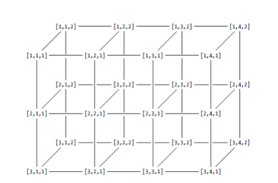

```r
AR <- array(data=1:24,dim=c(3,4,2))
AR
```

```
## , , 1
##
##      [,1] [,2] [,3] [,4]
## [1,]    1    4    7   10
## [2,]    2    5    8   11
## [3,]    3    6    9   12
##
## , , 2
##
##      [,1] [,2] [,3] [,4]
## [1,]   13   16   19   22
## [2,]   14   17   20   23
## [3,]   15   18   21   24
```

```r
BR <- array(data=rep(1:24,times=3),dim=c(3,4,2,3))
BR
```

```
## , , 1, 1
##
##      [,1] [,2] [,3] [,4]
## [1,]    1    4    7   10
## [2,]    2    5    8   11
## [3,]    3    6    9   12
##
## , , 2, 1
##
##      [,1] [,2] [,3] [,4]
## [1,]   13   16   19   22
## [2,]   14   17   20   23
## [3,]   15   18   21   24
##
## , , 1, 2
##
##      [,1] [,2] [,3] [,4]
## [1,]    1    4    7   10
## [2,]    2    5    8   11
## [3,]    3    6    9   12
##
## , , 2, 2
##
##      [,1] [,2] [,3] [,4]
## [1,]   13   16   19   22
## [2,]   14   17   20   23
## [3,]   15   18   21   24
##
## , , 1, 3
##
##      [,1] [,2] [,3] [,4]
## [1,]    1    4    7   10
## [2,]    2    5    8   11
## [3,]    3    6    9   12
##
## , , 2, 3
##
##      [,1] [,2] [,3] [,4]
## [1,]   13   16   19   22
## [2,]   14   17   20   23
## [3,]   15   18   21   24
```

### 2.3.2 Subsetting array

```r
AR[2,,2]
```

```r
AR[2,c(3,1),2]
```

```r
AR[1,,]
```

```r
BR[2,1,1,3]
```

```r
BR[1,,,1]
```

```r
BR[,,2,]
```

```r
BR[3:2,4,,]
```

```r
BR[2,,1,]
```

### 2.3.3 calculation across array elemets: apply function

```r
apply(x, margin, fun)
```

```r
apply(AR,1,sum) # calculate the sum of the rows across all the matrices, 1:row, 2:column
```

```
## [1]  92 100 108
```

```r
apply(AR,c(1,2),sum)
```

```
##      [,1] [,2] [,3] [,4]
## [1,]   14   20   26   32
## [2,]   16   22   28   34
## [3,]   18   24   30   36
```

advanced subsetting: http://adv-r.had.co.nz/Subsetting.html

## 2.4 Data.frame

A data frame is a named list of vectors with attributes for (column) names, row.names, and its class, “data.frame”:

data.frame de numerik, string ve faktorler (kategorik degiskenler) bulunabilir.

A tibble is modern version of data.frame

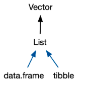

### 2.4.1 Creating data.frame

```r
DF1<-data.frame(D1 = v1, D2 = v2, D3 = v3)
DF1
```

| D1 | D2 | D3 |
| --- | --- | --- |
| 1 | 11 | 1 |
| 2 | 12 | 11 |
| 3 | 13 | 21 |
| 4 | NA | 31 |
| 5 | 15 | 41 |
| 6 | 16 | 51 |
| 7 | 17 | 61 |
| 8 | NA | 71 |
| 9 | 19 | 81 |
| 10 | 20 | 91 |

```r
class(DF1)
```

```
## [1] "data.frame"
```

```r
mode(DF1)
```

```
## [1] "list"
```

```r
typeof(DF1)
```

```
## [1] "list"
```

```r
attributes(DF1)
```

```
## $names
## [1] "D1" "D2" "D3"
##
## $class
## [1] "data.frame"
##
## $row.names
##  [1]  1  2  3  4  5  6  7  8  9 10
```

```r
names(DF1)
```

```
## [1] "D1" "D2" "D3"
```

```r
rownames(DF1)
```

```
##  [1] "1"  "2"  "3"  "4"  "5"  "6"  "7"  "8"  "9"  "10"
```

```r
colnames(DF1)
```

```
## [1] "D1" "D2" "D3"
```

```r
str(DF1)
```

```
## 'data.frame':    10 obs. of  3 variables:
##  $ D1: int  1 2 3 4 5 6 7 8 9 10
##  $ D2: num  11 12 13 NA 15 16 17 NA 19 20
##  $ D3: num  1 11 21 31 41 51 61 71 81 91
```

```r
is.matrix(DF1)
```

```
## [1] FALSE
```

```r
is.data.frame(DF1)
```

```
## [1] TRUE
```

```r
is.list(DF1)
```

```
## [1] TRUE
```

```r
ncol(DF1) # number of columns
```

```
## [1] 3
```

```r
nrow(DF1) # number of rows
```

```
## [1] 10
```

```r
length(DF1) # number of columns
```

```
## [1] 3
```

```r
dim(DF1)  # dimension
```

```
## [1] 10  3
```

```r
head(DF1)
```

|  | D1 | D2 | D3 |
| --- | --- | --- | --- |
| 1 | 1 | 11 | 1 |
| 2 | 2 | 12 | 11 |
| 3 | 3 | 13 | 21 |
| 4 | 4 | NA | 31 |
| 5 | 5 | 15 | 41 |
| 6 | 6 | 16 | 51 |

```r
head(DF1, 10)
```

|  | D1 | D2 | D3 |
| --- | --- | --- | --- |
| 1 | 1 | 11 | 1 |
| 2 | 2 | 12 | 11 |
| 3 | 3 | 13 | 21 |
| 4 | 4 | NA | 31 |
| 5 | 5 | 15 | 41 |
| 6 | 6 | 16 | 51 |
| 7 | 7 | 17 | 61 |
| 8 | 8 | NA | 71 |
| 9 | 9 | 19 | 81 |
| 10 | 10 | 20 | 91 |

```r
tail(DF1)
```

|  | D1 | D2 | D3 |
| --- | --- | --- | --- |
| 5 | 5 | 15 | 41 |
| 6 | 6 | 16 | 51 |
| 7 | 7 | 17 | 61 |
| 8 | 8 | NA | 71 |
| 9 | 9 | 19 | 81 |
| 10 | 10 | 20 | 91 |

```r
tail(DF1, 10)
```

|  | D1 | D2 | D3 |
| --- | --- | --- | --- |
| 1 | 1 | 11 | 1 |
| 2 | 2 | 12 | 11 |
| 3 | 3 | 13 | 21 |
| 4 | 4 | NA | 31 |
| 5 | 5 | 15 | 41 |
| 6 | 6 | 16 | 51 |
| 7 | 7 | 17 | 61 |
| 8 | 8 | NA | 71 |
| 9 | 9 | 19 | 81 |
| 10 | 10 | 20 | 91 |

```r
DF2<-data.frame(X1 = sqrt(v1), X2 = v2 + v3)
```

```r
DF3<- data.frame( x = 1:3, y = c("a", "b", "c"))
DF3
```

| x | y |
| --- | --- |
| 1 | a |
| 2 | b |
| 3 | c |

```r
str(DF3)
```

```
## 'data.frame':    3 obs. of  2 variables:
##  $ x: int  1 2 3
##  $ y: chr  "a" "b" "c"
```

```r
DF3<- data.frame( x = 1:3, y = c("a", "b", "c"), stringsAsFactors = FALSE)
str(DF3)
```

```
## 'data.frame':    3 obs. of  2 variables:
##  $ x: int  1 2 3
##  $ y: chr  "a" "b" "c"
```

### 2.4.2 Subsetting data.frame

```r
data(mtcars)
data(ToothGrowth)

str(mtcars) #structure
```

```
## 'data.frame':    32 obs. of  11 variables:
##  $ mpg : num  21 21 22.8 21.4 18.7 18.1 14.3 24.4 22.8 19.2 ...
##  $ cyl : num  6 6 4 6 8 6 8 4 4 6 ...
##  $ disp: num  160 160 108 258 360 ...
##  $ hp  : num  110 110 93 110 175 105 245 62 95 123 ...
##  $ drat: num  3.9 3.9 3.85 3.08 3.15 2.76 3.21 3.69 3.92 3.92 ...
##  $ wt  : num  2.62 2.88 2.32 3.21 3.44 ...
##  $ qsec: num  16.5 17 18.6 19.4 17 ...
##  $ vs  : num  0 0 1 1 0 1 0 1 1 1 ...
##  $ am  : num  1 1 1 0 0 0 0 0 0 0 ...
##  $ gear: num  4 4 4 3 3 3 3 4 4 4 ...
##  $ carb: num  4 4 1 1 2 1 4 2 2 4 ...
```

```r
str(ToothGrowth)
```

```
## 'data.frame':    60 obs. of  3 variables:
##  $ len : num  4.2 11.5 7.3 5.8 6.4 10 11.2 11.2 5.2 7 ...
##  $ supp: Factor w/ 2 levels "OJ","VC": 2 2 2 2 2 2 2 2 2 2 ...
##  $ dose: num  0.5 0.5 0.5 0.5 0.5 0.5 0.5 0.5 0.5 0.5 ...
```

```r
head(mtcars)
```

|  | mpg | cyl | disp | hp | drat | wt | qsec | vs | am | gear | carb |
| --- | --- | --- | --- | --- | --- | --- | --- | --- | --- | --- | --- |
| Mazda RX4 | 21.0 | 6 | 160 | 110 | 3.90 | 2.620 | 16.46 | 0 | 1 | 4 | 4 |
| Mazda RX4 Wag | 21.0 | 6 | 160 | 110 | 3.90 | 2.875 | 17.02 | 0 | 1 | 4 | 4 |
| Datsun 710 | 22.8 | 4 | 108 | 93 | 3.85 | 2.320 | 18.61 | 1 | 1 | 4 | 1 |
| Hornet 4 Drive | 21.4 | 6 | 258 | 110 | 3.08 | 3.215 | 19.44 | 1 | 0 | 3 | 1 |
| Hornet Sportabout | 18.7 | 8 | 360 | 175 | 3.15 | 3.440 | 17.02 | 0 | 0 | 3 | 2 |
| Valiant | 18.1 | 6 | 225 | 105 | 2.76 | 3.460 | 20.22 | 1 | 0 | 3 | 1 |

```r
head(ToothGrowth,10)
```

|  | len | supp | dose |
| --- | --- | --- | --- |
| 1 | 4.2 | VC | 0.5 |
| 2 | 11.5 | VC | 0.5 |
| 3 | 7.3 | VC | 0.5 |
| 4 | 5.8 | VC | 0.5 |
| 5 | 6.4 | VC | 0.5 |
| 6 | 10.0 | VC | 0.5 |
| 7 | 11.2 | VC | 0.5 |
| 8 | 11.2 | VC | 0.5 |
| 9 | 5.2 | VC | 0.5 |
| 10 | 7.0 | VC | 0.5 |

```r
mtcars$mpg
```

```
##  [1] 21.0 21.0 22.8 21.4 18.7 18.1 14.3 24.4 22.8 19.2 17.8 16.4 17.3 15.2 10.4
## [16] 10.4 14.7 32.4 30.4 33.9 21.5 15.5 15.2 13.3 19.2 27.3 26.0 30.4 15.8 19.7
## [31] 15.0 21.4
```

```r
mtcars[,1]
```

```
##  [1] 21.0 21.0 22.8 21.4 18.7 18.1 14.3 24.4 22.8 19.2 17.8 16.4 17.3 15.2 10.4
## [16] 10.4 14.7 32.4 30.4 33.9 21.5 15.5 15.2 13.3 19.2 27.3 26.0 30.4 15.8 19.7
## [31] 15.0 21.4
```

```r
attach(mtcars)
mpg
```

```
##  [1] 21.0 21.0 22.8 21.4 18.7 18.1 14.3 24.4 22.8 19.2 17.8 16.4 17.3 15.2 10.4
## [16] 10.4 14.7 32.4 30.4 33.9 21.5 15.5 15.2 13.3 19.2 27.3 26.0 30.4 15.8 19.7
## [31] 15.0 21.4
```

```r
detach(mtcars)
```

### 2.4.3 Coercion

```r
is.data.frame()
is_tibble()
as.data.frame()
as_tibble()
```

## 2.5 List

Lists are a step up in complexity from atomic vectors, because lists can contain other lists. This makes them suitable for representing hierarchical or tree-like structures

```r
list(...)
pairlist(...)
as.list(x, ...)
```

### 2.5.1 Creating list

```r
L1 <- list(1, 2, 3)
L1
```

```
## [[1]]
## [1] 1
##
## [[2]]
## [1] 2
##
## [[3]]
## [1] 3
```

```r
str(L1)
```

```
## List of 3
##  $ : num 1
##  $ : num 2
##  $ : num 3
```

The `typeof()` a list is list. You can test for a list with `is.list()` and coerce to a list with `as.list()`. You can turn a list into an atomic vector with `unlist()`. If the elements of a list have different types, `unlist()` uses the same coercion rules as `c()`.

Lists are used to build up many of the more complicated data structures in R. For example, both data frames and linear models objects (as produced by `lm()`) are lists:

```r
L2 <- list(1:10, c("Adana", "Bursa", "Mersin"), rnorm(10))
L2
```

```
## [[1]]
##  [1]  1  2  3  4  5  6  7  8  9 10
##
## [[2]]
## [1] "Adana"  "Bursa"  "Mersin"
##
## [[3]]
##  [1]  0.1835951 -1.8496759 -0.8883042  1.4224113 -0.4325355  0.0835700
##  [7] -0.3171062 -0.4283086  0.1148208  2.9174063
```

```r
names(L1) <- c("listinteger", "listcharacter", "listnumeric")
length(L1)
```

```
## [1] 3
```

```r
length(L1$listinteger)
```

```
## [1] 1
```

```r
L3 <- list(matrix(data=1:4,nrow=2,ncol=2),c(T,F,T,T),"hello")
length(x=L2)
```

```
## [1] 3
```

### 2.5.2 Subsetting list

```r
L3[[1]]
```

```
##      [,1] [,2]
## [1,]    1    3
## [2,]    2    4
```

```r
L3[[1]] + 5.5
```

```
##      [,1] [,2]
## [1,]  6.5  8.5
## [2,]  7.5  9.5
```

```r
L3
```

```
## [[1]]
##      [,1] [,2]
## [1,]    1    3
## [2,]    2    4
##
## [[2]]
## [1]  TRUE FALSE  TRUE  TRUE
##
## [[3]]
## [1] "hello"
```

```r
L3[[1]][1,2]
```

```
## [1] 3
```

```r
L3[[1]][2,]
```

```
## [1] 2 4
```

```r
cat(L3[[3]],"you!")
```

```
## hello you!
```

```r
L3[[3]]
```

```
## [1] "hello"
```

```r
L3[[3]] <- paste(L3[[3]],"you!")

L3[[c(2,2)]]
```

```
## [1] FALSE
```

```r
names(L3) <- c("mymatrix","mylogicals","mystring")
L3$mymatrix
```

```
##      [,1] [,2]
## [1,]    1    3
## [2,]    2    4
```

```r
L3[[1]]
```

```
##      [,1] [,2]
## [1,]    1    3
## [2,]    2    4
```

```r
all(L3$mymatrix[,2]==L3[[1]][,2])
```

```
## [1] TRUE
```

```r
L4 <- list(A1=c(L3[[2]],T,T,T,F), A2 = "AB2019",A3 = L3$mymatrix*2)
names(L4)
```

```
## [1] "A1" "A2" "A3"
```

```r
L4
```

```
## $A1
## [1]  TRUE FALSE  TRUE  TRUE  TRUE  TRUE  TRUE FALSE
##
## $A2
## [1] "AB2019"
##
## $A3
##      [,1] [,2]
## [1,]    2    6
## [2,]    4    8
```

```r
L4$A4 <- L3 # add list to list
L4
```

```
## $A1
## [1]  TRUE FALSE  TRUE  TRUE  TRUE  TRUE  TRUE FALSE
##
## $A2
## [1] "AB2019"
##
## $A3
##      [,1] [,2]
## [1,]    2    6
## [2,]    4    8
##
## $A4
## $A4$mymatrix
##      [,1] [,2]
## [1,]    1    3
## [2,]    2    4
##
## $A4$mylogicals
## [1]  TRUE FALSE  TRUE  TRUE
##
## $A4$mystring
## [1] "hello you!"
```

```r
names(L4)
```

```
## [1] "A1" "A2" "A3" "A4"
```

```r
L4$A4$mylogicals[1:3] # -o-o-
```

```
## [1]  TRUE FALSE  TRUE
```

```r
L4[[4]][[2]][1:3]
```

```
## [1]  TRUE FALSE  TRUE
```

```r
L4[[4]]$mylogicals[1:3]
```

```
## [1]  TRUE FALSE  TRUE
```

## 2.6 Factor

Nominal and ordinal variables are stored and treated specially in R. Factors are integer! vectors where each integer has a label. They sometimes behave like strings,and sometimes like integers

```r
factor(x = character(), levels, labels = levels,
       exclude = NA, ordered = is.ordered(x), nmax = NA)
```

### 2.6.1 Creating factor

**from character vector**

```r
x<-c("bir","iki","üç","dört","beş")
as.factor(x)
```

```
## [1] bir  iki  üç   dört beş
## Levels: beş bir dört iki üç
```

**from numeric vector**

```r
x<-c(1,2,2,1,3,1,3,2,1,1)
as.factor(x)
```

```
##  [1] 1 2 2 1 3 1 3 2 1 1
## Levels: 1 2 3
```

**from logical vector**

```r
x<- c(F,F,T,F,F,T)
as.factor(x)
```

```
## [1] FALSE FALSE TRUE  FALSE FALSE TRUE
## Levels: FALSE TRUE
```

```r
F1 <- factor(c("Small", "Small", "Medium","Large","Small", "Large"))
F1
```

```
## [1] Small  Small  Medium Large  Small  Large
## Levels: Large Medium Small
```

By default, factor levels for character vectors are created in alphabetical order.

```r
F1.2 <- factor(c("Small", "Small", "Medium","Large","Small", "Large"),ordered=TRUE)
F1.2
```

```
## [1] Small  Small  Medium Large  Small  Large
## Levels: Large < Medium < Small
```

```r
F1.3 <- factor(c("Small", "Small", "Medium","Large","Small", "Large"), ordered=TRUE, levels=c("Small","Medium","Large"))
F1.3
```

```
## [1] Small  Small  Medium Large  Small  Large
## Levels: Small < Medium < Large
```

```r
class(F1)
```

```
## [1] "factor"
```

```r
typeof(F1)
```

```
## [1] "integer"
```

```r
mode(F1)
```

```
## [1] "numeric"
```

```r
str(F1)
```

```
##  Factor w/ 3 levels "Large","Medium",..: 3 3 2 1 3 1
```

```r
F1[3]
```

```
## [1] Medium
## Levels: Large Medium Small
```

```r
unclass(F1)
```

```
## [1] 3 3 2 1 3 1
## attr(,"levels")
## [1] "Large"  "Medium" "Small"
```

```r
levels(F1)
```

```
## [1] "Large"  "Medium" "Small"
```

```r
summary(F1)
```

```
##  Large Medium  Small
##      2      1      3
```

```r
table(F1)
```

```
## F1
##  Large Medium  Small
##      2      1      3
```

```r
attributes(F1)
```

```
## $levels
## [1] "Large"  "Medium" "Small"
##
## $class
## [1] "factor"
```

## 2.7 Time series

Time series are created with `ts()` function of base installation. For working with irregular time series and advanced manipulation, additional packages are needed.

### 2.7.1 Creating ts

```r
ts(data = NA, start = 1, end = numeric(), frequency = 1,
   deltat = 1, ts.eps = getOption("ts.eps"), class = , names = )
as.ts(x, ...)
is.ts(x)
```

```r
ts(1:10, frequency = 4, start = c(2018, 2))
```

```
##      Qtr1 Qtr2 Qtr3 Qtr4
## 2018         1    2    3
## 2019    4    5    6    7
## 2020    8    9   10
```

```r
ts1 <- ts(matrix(rnorm(300), 100, 3), start = c(2010, 1), frequency = 12)
head(ts1)
```

```
##         Series 1    Series 2   Series 3
## [1,]  0.20176083 -1.60536768 -0.6254453
## [2,] -2.53761082  0.93776383 -1.8441114
## [3,] -2.46024465 -0.01154022 -0.3923763
## [4,] -1.45354319 -1.93392885  0.3487340
## [5,]  0.02764953  1.36163354 -1.0268932
## [6,]  0.95353527 -1.08828814 -0.9931010
```

```r
class(ts1)
```

```
## [1] "mts"    "ts"     "matrix"
```

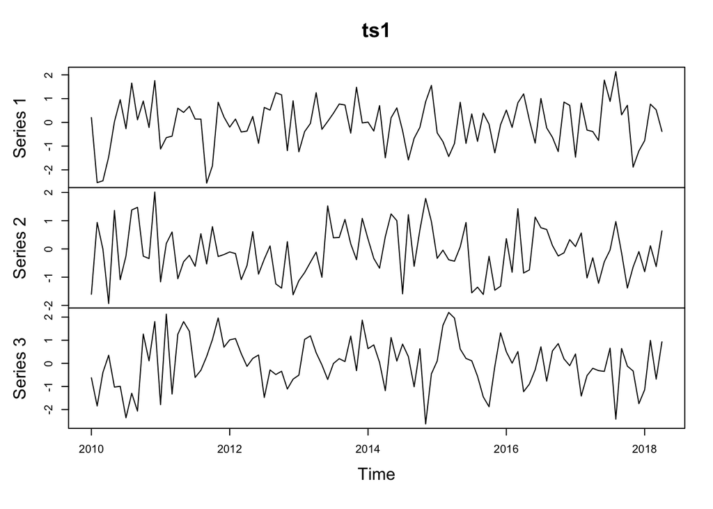

```r
plot(ts1)
```

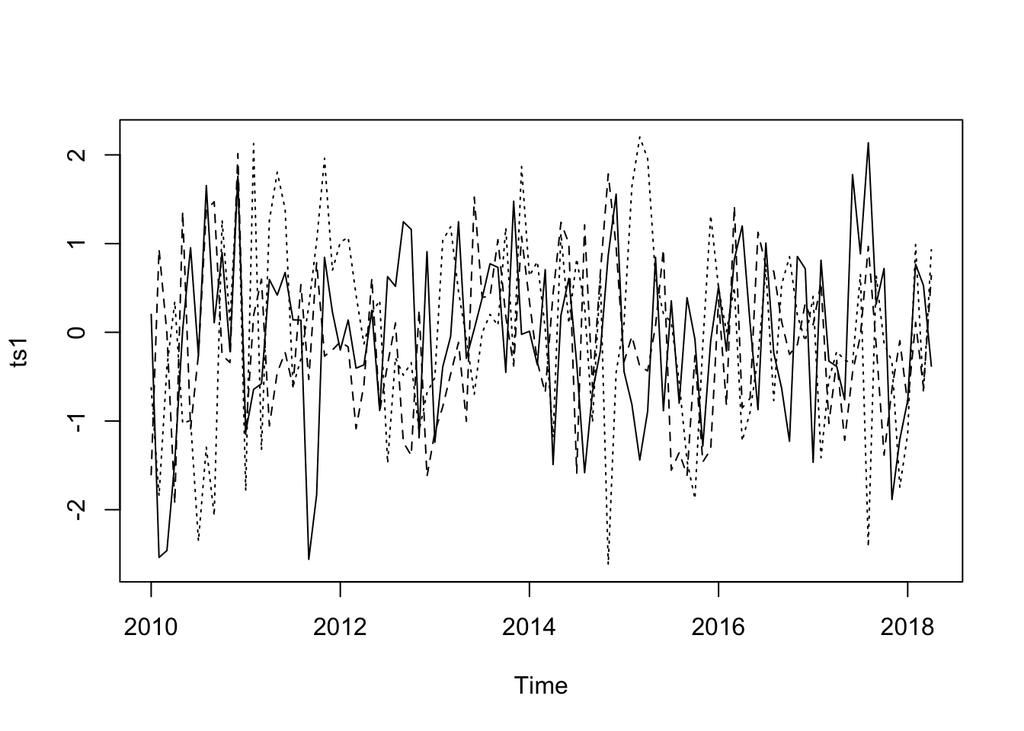

```r
plot(ts1, plot.type = "single", lty = 1:3)
```

```r
data(Nile)
Nile
```

```
## Time Series:
## Start = 1871
## End = 1970
## Frequency = 1
##   [1] 1120 1160  963 1210 1160 1160  813 1230 1370 1140  995  935 1110  994 1020
##  [16]  960 1180  799  958 1140 1100 1210 1150 1250 1260 1220 1030 1100  774  840
##  [31]  874  694  940  833  701  916  692 1020 1050  969  831  726  456  824  702
##  [46] 1120 1100  832  764  821  768  845  864  862  698  845  744  796 1040  759
##  [61]  781  865  845  944  984  897  822 1010  771  676  649  846  812  742  801
##  [76] 1040  860  874  848  890  744  749  838 1050  918  986  797  923  975  815
##  [91] 1020  906  901 1170  912  746  919  718  714  740
```